# Field Mapping of Knowledge Structure: AI & INdustry Dynamics

Daniel S. Hain

11 September, 2023

# Introduction: Mapping of broad research field around AI, v1

Here are preliminary results of the bibliometric mapping of the research field. Its purpose is:

- To map the broader research community and distinct research field the department contributes to.
- Identify core knowledge bases, research areas gtrends and topics.
- Highlight the positioning of the department within this dynamics.

The method for the research-field-mapping can be reviewed here:

[Rakas, M., & Hain, D. S. (2019). The state of innovation system research: What happens beneath the surface?. Research Policy, 48(9), 103787.](https://doi.org/10.1016/j.respol.2019.04.011)

**Note:** The analysis in this document depicts the *larger research field* around the department, thereby all analysis results are based on the publications of the department plus related.

## Seed articles

[output not shown]

| AU | PY | TI | SO |
| --- | --- | --- | --- |
| MARIANI MM;MACHADO I;MAGRELLI V;DWIVEDI YK | 2023 | ARTIFICIAL INTELLIGENCE IN INNOVATION RESEARCH: A SYSTEMATIC REVIEW, CONCEPTUAL FRAMEWORK, AND FUTURE RESEARCH DIRECTIONS | TECHNOVATION |
| MARIANI MM;MACHADO I;NAMBISAN S | 2023 | TYPES OF INNOVATION AND ARTIFICIAL INTELLIGENCE: A SYSTEMATIC QUANTITATIVE LITERATURE REVIEW AND RESEARCH AGENDA | JOURNAL OF BUSINESS RESEARCH |
| VENTURINI F | 2022 | INTELLIGENT TECHNOLOGIES AND PRODUCTIVITY SPILLOVERS: EVIDENCE FROM THE FOURTH INDUSTRIAL REVOLUTION | JOURNAL OF ECONOMIC BEHAVIOR AND ORGANIZATION |

# General Overview over the research field

**Note:** This section provides basic descriptives of th identified research fielld, including number of articles over time, countries, institutions, and authors. See `Technical description`for additional explanations.

## Main Indicators: Publications, Authors, Countries

### Corpus summary tabular

```
##
##
## MAIN INFORMATION ABOUT DATA
##
##  Timespan                              1992 : 2023
##  Sources (Journals, Books, etc)        331
##  Documents                             805
##  Annual Growth Rate %                  8.04
##  Document Average Age                  4.31
##  Average citations per doc             99.49
##  Average citations per year per doc    22.23
##  References                            57537
##
## DOCUMENT TYPES
##               13
##  article      792
##
## DOCUMENT CONTENTS
##  Keywords Plus (ID)                    2522
##  Author's Keywords (DE)                2367
##
## AUTHORS
##  Authors                               2164
##  Author Appearances                    2680
##  Authors of single-authored docs       93
##
## AUTHORS COLLABORATION
##  Single-authored docs                  99
##  Documents per Author                  0.372
##  Co-Authors per Doc                    3.33
##  International co-authorships %        46.09
##
##
## Annual Scientific Production
##
##  Year    Articles
##     1992        1
##     1997        1
##     1999        2
##     2000        4
```

[output cut: 104 more lines]

```
##
##
## Most Relevant Keywords
##
##    Author Keywords (DE)      Articles    Keywords-Plus (ID)     Articles
## 1    ARTIFICIAL INTELLIGENCE      212 ARTIFICIAL INTELLIGENCE        150
## 2    BIG DATA                      75 INNOVATION                      64
## 3    MACHINE LEARNING              51 DECISION MAKING                 62
## 4    INDUSTRY 4 0                  42 BIG DATA                        52
## 5    DIGITAL TRANSFORMATION        39 TECHNOLOGY ADOPTION             48
## 6    DIGITALIZATION                34 TECHNOLOGICAL DEVELOPMENT       41
## 7    INNOVATION                    31 CHINA                           33
## 8    BIG DATA ANALYTICS            30 DATA ANALYTICS                  30
## 9    AUTOMATION                    29 INDUSTRY 4 0                    29
## 10   DYNAMIC CAPABILITIES          25 SUSTAINABLE DEVELOPMENT         29
```

### Corpus summary graphical

[figure not shown]

[figure not shown]

[figure not shown]

[figure not shown]

[figure not shown]

[figure not shown]

# Knowledge Bases: Co-Citation network analysis

**Note:** This analysis refers the co-citation analysis, where the cited references and not the original publications are the unit of analysis. Identified knowledge bases can be interpreted as the knowledge foundation the field draws from. See `Technical description`for additional explanations.

| name | dgr_int | dgr |
| --- | --- | --- |
| **Knowledge Base 1: KB 1: Big Data-Driven Business Competence (n = 255, density =14.92)** |  |  |
| EREVELLES S. FUKAWA N. SWAYNE L. BIG DATA CONSUMER ANALYTICS AND THE TRANSFORMATION OF MARKETING (2016) | 677 | 1395 |
| AKTER S. WAMBA S.F. GUNASEKARAN A. DUBEY R. CHILDE S.J. HOW TO IMPROVE FIRM PERFORMANCE USING BIG DATA ANALYTICS CAPABILITY AND BUSINESS STRATEGY A… | 594 | 976 |
| GANDOMI A. HAIDER M. BEYOND THE HYPE: BIG DATA CONCEPTS METHODS AND ANALYTICS (2015) | 380 | 504 |
| BARNEY J. FIRM RESOURCES AND SUSTAINED COMPETITIVE ADVANTAGE (1991) | 378 | 822 |
| MCAFEE A. BRYNJOLFSSON E. BIG DATA: THE MANAGEMENT REVOLUTION (2012) | 290 | 392 |
| WAMBA S.F. GUNASEKARAN A. AKTER S. REN S.J.F. DUBEY R. CHILDE S.J. BIG DATA ANALYTICS AND FIRM PERFORMANCE: EFFECTS OF DYNAMIC CAPABILITIES (2017) | 283 | 517 |
| SIVARAJAH U. KAMAL M.M. IRANI Z. WEERAKKODY V. CRITICAL ANALYSIS OF BIG DATA CHALLENGES AND ANALYTICAL METHODS (2017) | 217 | 272 |
| CHEN D.Q. PRESTON D.S. SWINK M. HOW THE USE OF BIG DATA ANALYTICS AFFECTS VALUE CREATION IN SUPPLY CHAIN MANAGEMENT (2015) | 212 | 317 |
| CÔRTE-REAL N. OLIVEIRA T. RUIVO P. ASSESSING BUSINESS VALUE OF BIG DATA ANALYTICS IN EUROPEAN FIRMS (2017) | 201 | 394 |
| GUNASEKARAN A. PAPADOPOULOS T. DUBEY R. WAMBA S.F. CHILDE S.J. HAZEN B. AKTER S. BIG DATA AND PREDICTIVE ANALYTICS FOR SUPPLY CHAIN AND ORGANIZATIO… | 198 | 271 |
| **Knowledge Base 2: KB 2: Digital Servitization & Dynamic Capabilities (n = 253, density =9.69)** |  |  |
| TEECE D.J. PISANO G. SHUEN A. DYNAMIC CAPABILITIES AND STRATEGIC MANAGEMENT (1997) | 619 | 1464 |
| EISENHARDT K.M. BUILDING THEORIES FROM CASE STUDY RESEARCH (1989) | 273 | 376 |
| TEECE D.J. EXPLICATING DYNAMIC CAPABILITIES: THE NATURE AND MICROFOUNDATIONS OF (SUSTAINABLE) | 243 | 492 |
| EISENHARDT K.M. MARTIN J.A. DYNAMIC CAPABILITIES: WHAT ARE THEY? (2000) | 228 | 666 |
| EISENHARDT K.M. GRAEBNER M.E. THEORY BUILDING FROM CASES: OPPORTUNITIES AND CHALLENGES (2007) | 201 | 223 |
| MATT C. HESS T. BENLIAN A. DIGITAL TRANSFORMATION STRATEGIES (2015) | 168 | 180 |
| NAMBISAN S. WRIGHT M. FELDMAN M. THE DIGITAL TRANSFORMATION OF INNOVATION AND ENTREPRENEURSHIP: PROGRESS CHALLENGES AND KEY THEMES (2019) | 165 | 165 |
| NAMBISAN S. DIGITAL ENTREPRENEURSHIP: TOWARD A DIGITAL TECHNOLOGY PERSPECTIVE OF ENTREPRENEURSHIP (2017) | 148 | 180 |
| TEECE D.J. BUSINESS MODELS BUSINESS STRATEGY AND INNOVATION (2010) | 126 | 132 |
| NAMBISAN S. LYYTINEN K. MAJCHRZAK A. SONG M. DIGITAL INNOVATION MANAGEMENT: REINVENTING INNOVATION MANAGEMENT RESEARCH IN A DIGITAL WORLD (2017) | 118 | 145 |
| **Knowledge Base 3: KB 3: Robotics in Hospitality (n = 249, density =17.16)** |  |  |
| HUANG M.H. RUST R.T. ARTIFICIAL INTELLIGENCE IN SERVICE (2018) | 534 | 718 |
| WIRTZ J. PATTERSON P.G. KUNZ W.H. GRUBER T. LU V.N. PALUCH S. MARTINS A. BRAVE NEW WORLD: SERVICE ROBOTS IN THE FRONTLINE (2018) | 518 | 633 |
| LU L. CAI R. GURSOY D. DEVELOPING AND VALIDATING A SERVICE ROBOT INTEGRATION WILLINGNESS SCALE (2019) | 512 | 558 |
| MURPHY J. GRETZEL U. PESONEN J. MARKETING ROBOT SERVICES IN HOSPITALITY AND TOURISM: THE ROLE OF ANTHROPOMORPHISM (2019) | 449 | 472 |
| TUNG V.W.S. AU N. EXPLORING CUSTOMER EXPERIENCES WITH ROBOTICS IN HOSPITALITY (2018) | 335 | 349 |
| TUSSYADIAH I.P. PARK S. CONSUMER EVALUATION OF HOTEL SERVICE ROBOTS (2018) | 323 | 333 |
| BELANCHE D. CASALÓ L.V. FLAVIÁN C. SCHEPERS J. SERVICE ROBOT IMPLEMENTATION: A THEORETICAL FRAMEWORK AND RESEARCH AGENDA (2020) | 271 | 289 |
| MENDE M. SCOTT M.L. VAN DOORN J. GREWAL D. SHANKS I. SERVICE ROBOTS RISING: HOW HUMANOID ROBOTS INFLUENCE SERVICE EXPERIENCES AND ELICIT COMPENSATO… | 249 | 265 |
| IVANOV S. GRETZEL U. BEREZINA K. SIGALA M. WEBSTER C. PROGRESS ON ROBOTICS IN HOSPITALITY AND TOURISM: A REVIEW OF THE LITERATURE (2019) | 245 | 261 |
| MURPHY J. HOFACKER C. GRETZEL U. DAWNING OF THE AGE OF ROBOTS IN HOSPITALITY AND TOURISM: CHALLENGES FOR TEACHING AND RESEARCH (2017) | 228 | 242 |
| **Knowledge Base 4: KB 4: AI-Driven Organizational Transformation (n = 222, density =10.51)** |  |  |
| JARRAHI M.H. ARTIFICIAL INTELLIGENCE AND THE FUTURE OF WORK: HUMAN-AI SYMBIOSIS IN ORGANIZATIONAL DECISION MAKING (2018) | 214 | 253 |
| FREY C.B. OSBORNE M.A. THE FUTURE OF EMPLOYMENT: HOW SUSCEPTIBLE ARE JOBS TO COMPUTERISATION? (2017) | 171 | 224 |
| DAVENPORT T.H. RONANKI R. ARTIFICIAL INTELLIGENCE FOR THE REAL WORLD (2018) | 147 | 171 |
| DUAN Y. EDWARDS J.S. DWIVEDI Y.K. ARTIFICIAL INTELLIGENCE FOR DECISION MAKING IN THE ERA OF BIG DATA–EVOLUTION CHALLENGES AND RESEARCH AGENDA (2019) | 132 | 201 |
| FOUNTAINE T. MCCARTHY B. SALEH T. BUILDING THE AI-POWERED ORGANIZATION (2019) | 125 | 135 |
| BRYNJOLFSSON E. MCAFEE A. (2014) | 121 | 127 |
| GROVER P. KAR A.K. DWIVEDI Y.K. UNDERSTANDING ARTIFICIAL INTELLIGENCE ADOPTION IN OPERATIONS MANAGEMENT: INSIGHTS FROM THE REVIEW OF ACADEMIC LITER… | 121 | 164 |
| DAVENPORT T. GUHA A. GREWAL D. BRESSGOTT T. HOW ARTIFICIAL INTELLIGENCE WILL CHANGE THE FUTURE OF MARKETING (2020) | 119 | 167 |
| WILSON H.J. DAUGHERTY P.R. COLLABORATIVE INTELLIGENCE: HUMANS AND AI ARE JOINING FORCES (2018) | 117 | 134 |
| HAENLEIN M. KAPLAN A. A BRIEF HISTORY OF ARTIFICIAL INTELLIGENCE: ON THE PAST PRESENT AND FUTURE OF ARTIFICIAL INTELLIGENCE (2019) | 114 | 146 |
| **Knowledge Base 5: KB 5: Technology Acceptance Dynamics (n = 169, density =11.98)** |  |  |
| DAVIS F.D. PERCEIVED USEFULNESS PERCEIVED EASE OF USE AND USER ACCEPTANCE OF INFORMATION TECHNOLOGY (1989) | 360 | 538 |
| FORNELL C. LARCKER D.F. EVALUATING STRUCTURAL EQUATION MODELS WITH UNOBSERVABLE VARIABLES AND MEASUREMENT ERROR (1981) | 340 | 979 |
| VENKATESH V. MORRIS M.G. DAVIS G.B. DAVIS F.D. USER ACCEPTANCE OF INFORMATION TECHNOLOGY: TOWARD A UNIFIED VIEW (2003) | 232 | 370 |
| VENKATESH V. DAVIS F.D. A THEORETICAL EXTENSION OF THE TECHNOLOGY ACCEPTANCE MODEL: FOUR LONGITUDINAL FIELD STUDIES (2000) | 178 | 291 |
| AJZEN I. THE THEORY OF PLANNED BEHAVIOR (1991) | 121 | 136 |
| DAVIS F.D. BAGOZZI R.P. WARSHAW P.R. USER ACCEPTANCE OF COMPUTER TECHNOLOGY: A COMPARISON OF TWO THEORETICAL MODELS (1989) | 105 | 115 |
| PODSAKOFF P.M. MACKENZIE S.B. LEE J.Y. PODSAKOFF N.P. COMMON METHOD BIASES IN BEHAVIORAL RESEARCH: A CRITICAL REVIEW OF THE LITERATURE AND RECOMMEN… | 93 | 255 |
| HENSELER J. RINGLE C.M. SINKOVICS R.R. THE USE OF PARTIAL LEAST SQUARES PATH MODELING IN INTERNATIONAL MARKETING (2009) | 85 | 116 |
| ANDERSON J.C. GERBING D.W. STRUCTURAL EQUATION MODELING IN PRACTICE: A REVIEW AND RECOMMENDED TWO-STEP APPROACH (1988) | 83 | 122 |
| VENKATESH V. THONG J.Y. XU X. CONSUMER ACCEPTANCE AND USE OF INFORMATION TECHNOLOGY: EXTENDING THE UNIFIED THEORY OF ACCEPTANCE AND USE OF TECHNOLO… | 78 | 101 |
| **Knowledge Base 6: KB 6: Big Data-Driven Competitive Dynamics (n = 144, density =57.7)** |  |  |
| GUPTA M. GEORGE J.F. TOWARD THE DEVELOPMENT OF A BIG DATA ANALYTICS CAPABILITY (2016) | 568 | 1187 |
| LAVALLE S. LESSER E. SHOCKLEY R. HOPKINS M.S. KRUSCHWITZ N. BIG DATA ANALYTICS AND THE PATH FROM INSIGHTS TO VALUE (2011) | 443 | 867 |
| CHEN H. CHIANG R.H. STOREY V.C. BUSINESS INTELLIGENCE AND ANALYTICS: FROM BIG DATA TO BIG IMPACT (2012) | 331 | 688 |
| GRANT R.M. THE RESOURCE-BASED THEORY OF COMPETITIVE ADVANTAGE: IMPLICATIONS FOR STRATEGY FORMULATION (1991) | 297 | 348 |
| MIKALEF P. PATELI A. INFORMATION TECHNOLOGY-ENABLED DYNAMIC CAPABILITIES AND THEIR INDIRECT EFFECT ON COMPETITIVE PERFORMANCE: FINDINGS FROM PLS-SE… | 291 | 411 |
| VIDGEN R. SHAW S. GRANT D.B. MANAGEMENT CHALLENGES IN CREATING VALUE FROM BUSINESS ANALYTICS (2017) | 277 | 369 |
| ABBASI A. SARKER S. CHIANG R.H. BIG DATA RESEARCH IN INFORMATION SYSTEMS: TOWARD AN INCLUSIVE RESEARCH AGENDA (2016) | 276 | 399 |
| MIKALEF P. PAPPAS I.O. KROGSTIE J. GIANNAKOS M. BIG DATA ANALYTICS CAPABILITIES: A SYSTEMATIC LITERATURE REVIEW AND RESEARCH AGENDA (2018) | 275 | 344 |
| PODSAKOFF P.M. MACKENZIE S.B. LEE J.-Y. PODSAKOFF N.P. COMMON METHOD BIASES IN BEHAVIORAL RESEARCH: A CRITICAL REVIEW OF THE LITERATURE AND RECOMME… | 264 | 447 |
| HAIR J.F. RINGLE C.M. SARSTEDT M. PLS-SEM: INDEED A SILVER BULLET (2011) | 250 | 407 |

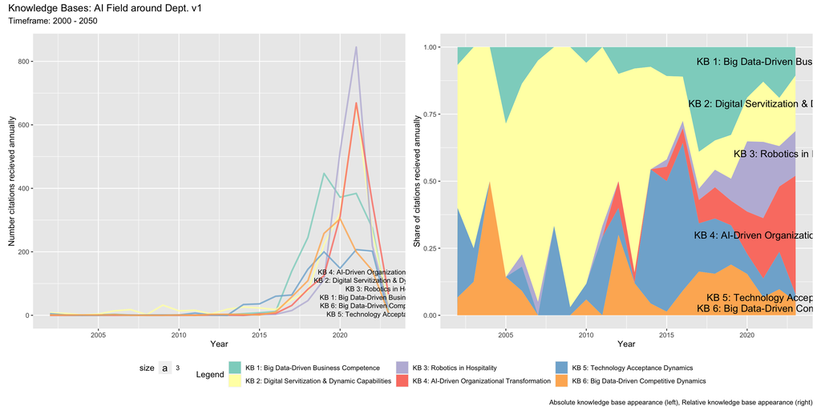

## Automated (LMM) summary

Works a bit less precise, since it only has titles and no abstracts

```
## Label: KB 1: Big Data-Driven Business Competence
##   Description: The provided body of work delves into the transformative influence of Big Data analytics on business and organizational performance. At its core, these articles emphasize the strategic alignment of Big Data capabilities with business objectives, elucidating the potential of data-dr…
##
##
## Label: KB 2: Digital Servitization and Dynamic Capabilities
##   Description: The body of work predominantly revolves around the transformative effects of digitalization on industrial dynamics, specifically emphasizing the concepts of "Digital Servitization" and "Dynamic Capabilities." Digital Servitization denotes the use of digital technologies by manufact…
##
##
## Label: KB 3: Robotics in Hospitality
##   Description: This body of research predominantly delves into the integration and impact of robotic and artificial intelligence (AI) technologies in the hospitality and tourism sectors. These studies often explore customer perceptions and experiences with robotic services, gauging the appropriat…
##
##
## Label: KB 4: AI-Driven Organizational Transformation
##   Description: The given collection of articles predominantly revolves around the transformative impact of artificial intelligence (AI) on organizational dynamics, decision-making, and the broader landscape of work. Key themes that emerge include the symbiotic relationship between humans and AI i…
##
##
## Label: KB 5: Technology Acceptance Dynamics
##   Description: The overarching theme across these documents delves into the understanding of technology acceptance dynamics, specifically focusing on factors influencing the adoption of emerging and innovative information technologies. Central to the discourse is the Technology Acceptance Model (…
##
##
## Label: KB 6: Big Data-Driven Competitive Dynamics
##   Description: The overarching theme of the presented documents revolves around the profound influence of big data analytics on organizational dynamics, competitiveness, and innovation. Central to this research is the idea that big data, when coupled with appropriate analytical capabilities, can …
##
##
```

# Research Areas: Bibliographic coupling analysis

**Note:** This analysis refers the bibliographic coupling analysis, where original publications are the unit of analysis. Identified research areas can be interpreted as the field’s current research frontier. See `Technical description`for additional explanations.

| AU | PY | TI | dgr_int | TC | TC_year |
| --- | --- | --- | --- | --- | --- |
| **Research Area 1: RA 1: Big Data Analytics & Dynamic Capabilities (n = 121, density =0.95)** |  |  |  |  |  |
| MIKALEF P;PAPPAS IO;KR… | 2018 | BIG DATA ANALYTICS CAPABILITIES: A SYSTEMATIC LITERATURE REVIEW AND RESEARCH AGENDA | 2.95 | 391 | 97.75 |
| MIKALEF P;BOURA M;LEKA… | 2019 | BIG DATA ANALYTICS CAPABILITIES AND INNOVATION: THE MEDIATING ROLE OF DYNAMIC CAPABILITIES AND MODERATING EFFECT OF THE EN… | 3.41 | 292 | 97.33 |
| MIKALEF P;KROGSTIE J;P… | 2020 | EXPLORING THE RELATIONSHIP BETWEEN BIG DATA ANALYTICS CAPABILITY AND COMPETITIVE PERFORMANCE: THE MEDIATING ROLES OF DYNAM… | 3.22 | 309 | 154.50 |
| RIALTI R;ZOLLO L;FERRA… | 2019 | BIG DATA ANALYTICS CAPABILITIES AND PERFORMANCE: EVIDENCE FROM A MODERATED MULTI-MEDIATION MODEL | 2.96 | 187 | 62.33 |
| KACHE F;SEURING S | 2017 | CHALLENGES AND OPPORTUNITIES OF DIGITAL INFORMATION AT THE INTERSECTION OF BIG DATA ANALYTICS AND SUPPLY CHAIN MANAGEMENT | 1.15 | 455 | 91.00 |
| DUBEY R;GUNASEKARAN A;… | 2020 | BIG DATA ANALYTICS AND ARTIFICIAL INTELLIGENCE PATHWAY TO OPERATIONAL PERFORMANCE UNDER THE EFFECTS OF ENTREPRENEURIAL ORI… | 1.94 | 244 | 122.00 |
| GROVER V;CHIANG RHL;LI… | 2018 | CREATING STRATEGIC BUSINESS VALUE FROM BIG DATA ANALYTICS: A RESEARCH FRAMEWORK | 0.83 | 453 | 113.25 |
| RIALTI R;MARZI G;CIAPP… | 2019 | BIG DATA AND DYNAMIC CAPABILITIES: A BIBLIOMETRIC ANALYSIS AND SYSTEMATIC LITERATURE REVIEW | 3.19 | 114 | 38.00 |
| POPOVIČ A;HACKNEY R;TA… | 2018 | THE IMPACT OF BIG DATA ANALYTICS ON FIRMS’ HIGH VALUE BUSINESS PERFORMANCE | 1.91 | 169 | 42.25 |
| GHASEMAGHAEI M;CALIC G | 2020 | ASSESSING THE IMPACT OF BIG DATA ON FIRM INNOVATION PERFORMANCE: BIG DATA IS NOT ALWAYS BETTER DATA | 2.17 | 140 | 70.00 |
| **Research Area 2: RA 2: Robotic Services in Hospitality (n = 115, density =0.73)** |  |  |  |  |  |
| KIM SS;KIM J;BADU-BAID… | 2021 | PREFERENCE FOR ROBOT SERVICE OR HUMAN SERVICE IN HOTELS? IMPACTS OF THE COVID-19 PANDEMIC | 2.14 | 243 | 243.00 |
| WIRTZ J;PATTERSON PG;K… | 2018 | BRAVE NEW WORLD: SERVICE ROBOTS IN THE FRONTLINE | 0.62 | 810 | 202.50 |
| JIANG Y;WEN J | 2020 | EFFECTS OF COVID-19 ON HOTEL MARKETING AND MANAGEMENT: A PERSPECTIVE ARTICLE | 0.87 | 454 | 227.00 |
| DE KERVENOAEL R;HASAN … | 2020 | LEVERAGING HUMAN-ROBOT INTERACTION IN HOSPITALITY SERVICES: INCORPORATING THE ROLE OF PERCEIVED VALUE, EMPATHY, AND INFORM… | 1.79 | 216 | 108.00 |
| DAVENPORT T;GUHA A;GRE… | 2020 | HOW ARTIFICIAL INTELLIGENCE WILL CHANGE THE FUTURE OF MARKETING | 0.62 | 577 | 288.50 |
| HUANG M-H;RUST RT | 2018 | ARTIFICIAL INTELLIGENCE IN SERVICE | 0.27 | 1053 | 263.25 |
| HUANG M-H;RUST RT | 2021 | A STRATEGIC FRAMEWORK FOR ARTIFICIAL INTELLIGENCE IN MARKETING | 1.18 | 233 | 233.00 |
| CHOI Y;CHOI M;OH M;KIM S | 2020 | SERVICE ROBOTS IN HOTELS: UNDERSTANDING THE SERVICE QUALITY PERCEPTIONS OF HUMAN-ROBOT INTERACTION | 1.48 | 165 | 82.50 |
| GURSOY D;CHI OH;LU L;N… | 2019 | CONSUMERS ACCEPTANCE OF ARTIFICIALLY INTELLIGENT (AI) DEVICE USE IN SERVICE DELIVERY | 0.70 | 340 | 113.33 |
| TUSSYADIAH I | 2020 | A REVIEW OF RESEARCH INTO AUTOMATION IN TOURISM: LAUNCHING THE ANNALS OF TOURISM RESEARCH CURATED COLLECTION ON ARTIFICIAL… | 0.91 | 248 | 124.00 |
| **Research Area 3: RA 3: Dynamic Digital Servitization (n = 108, density =0.35)** |  |  |  |  |  |
| MATARAZZO M;PENCO L;PR… | 2021 | DIGITAL TRANSFORMATION AND CUSTOMER VALUE CREATION IN MADE IN ITALY SMES: A DYNAMIC CAPABILITIES PERSPECTIVE | 0.89 | 279 | 279.00 |
| RACHINGER M;RAUTER R;M… | 2019 | DIGITALIZATION AND ITS INFLUENCE ON BUSINESS MODEL INNOVATION | 0.49 | 400 | 133.33 |
| NADKARNI S;PRÜGL R | 2021 | DIGITAL TRANSFORMATION: A REVIEW, SYNTHESIS AND OPPORTUNITIES FOR FUTURE RESEARCH | 0.81 | 188 | 188.00 |
| BAI C;DALLASEGA P;ORZE… | 2020 | INDUSTRY 4.0 TECHNOLOGIES ASSESSMENT: A SUSTAINABILITY PERSPECTIVE | 0.30 | 458 | 229.00 |
| SAARIKKO T;WESTERGREN … | 2020 | DIGITAL TRANSFORMATION: FIVE RECOMMENDATIONS FOR THE DIGITALLY CONSCIOUS FIRM | 1.01 | 121 | 60.50 |
| CULOT G;NASSIMBENI G;O… | 2020 | BEHIND THE DEFINITION OF INDUSTRY 4.0: ANALYSIS AND OPEN QUESTIONS | 0.36 | 302 | 151.00 |
| BENITEZ GB;AYALA NF;FR… | 2020 | INDUSTRY 4.0 INNOVATION ECOSYSTEMS: AN EVOLUTIONARY PERSPECTIVE ON VALUE COCREATION | 0.45 | 221 | 110.50 |
| GUO H;YANG Z;HUANG R;G… | 2020 | THE DIGITALIZATION AND PUBLIC CRISIS RESPONSES OF SMALL AND MEDIUM ENTERPRISES: IMPLICATIONS FROM A COVID-19 SURVEY | 0.64 | 141 | 70.50 |
| LINDE L;SJÖDIN D;PARID… | 2021 | DYNAMIC CAPABILITIES FOR ECOSYSTEM ORCHESTRATION A CAPABILITY-BASED FRAMEWORK FOR SMART CITY INNOVATION INITIATIVES | 0.97 | 91 | 91.00 |
| SOLUK J;KAMMERLANDER N | 2021 | DIGITAL TRANSFORMATION IN FAMILY-OWNED MITTELSTAND FIRMS: A DYNAMIC CAPABILITIES PERSPECTIVE | 1.01 | 85 | 85.00 |
| **Research Area 4: RA 4: Digitalization-Driven Labor Dynamics (n = 93, density =0.28)** |  |  |  |  |  |
| ACEMOGLU D;RESTREPO P | 2020 | ROBOTS AND JOBS: EVIDENCE FROM US LABOR MARKETS | 0.87 | 582 | 291.00 |
| ARNTZ M;GREGORY T;ZIER… | 2017 | REVISITING THE RISK OF AUTOMATION | 0.66 | 204 | 40.80 |
| HIRSCHI A | 2018 | THE FOURTH INDUSTRIAL REVOLUTION: ISSUES AND IMPLICATIONS FOR CAREER RESEARCH AND PRACTICE | 0.62 | 207 | 51.75 |
| RAISCH S;KRAKOWSKI S | 2021 | ARTIFICIAL INTELLIGENCE AND MANAGEMENT: THE AUTOMATION–AUGMENTATION PARADOX | 0.36 | 319 | 319.00 |
| AUTOR D;SALOMONS A | 2018 | IS AUTOMATION LABOR SHARE–DISPLACING? PRODUCTIVITY GROWTH, EMPLOYMENT, AND THE LABOR SHARE | 0.80 | 121 | 30.25 |
| FARAJ S;PACHIDI S;SAYE… | 2018 | WORKING AND ORGANIZING IN THE AGE OF THE LEARNING ALGORITHM | 0.27 | 245 | 61.25 |
| SHESTAKOFSKY B | 2017 | WORKING ALGORITHMS: SOFTWARE AUTOMATION AND THE FUTURE OF WORK | 0.77 | 82 | 16.40 |
| RUSSELL S;DEWEY D;TEGM… | 2015 | RESEARCH PRIORITIES FOR ROBUST AND BENEFICIAL ARTIFICIAL INTELLIGENCE | 0.20 | 319 | 45.57 |
| MCCLURE PK | 2018 | “YOU’RE FIRED,” SAYS THE ROBOT: THE RISE OF AUTOMATION IN THE WORKPLACE, TECHNOPHOBES, AND FEARS OF UNEMPLOYMENT | 0.44 | 132 | 33.00 |
| BOYD R;HOLTON RJ | 2018 | TECHNOLOGY, INNOVATION, EMPLOYMENT AND POWER: DOES ROBOTICS AND ARTIFICIAL INTELLIGENCE REALLY MEAN SOCIAL TRANSFORMATION? | 0.50 | 97 | 24.25 |
| **Research Area 5: RA 5: Open Innovation & Sustainable Digitalization (n = 80, density =0.3)** |  |  |  |  |  |
| DONTHU N;KUMAR S;MUKHE… | 2021 | HOW TO CONDUCT A BIBLIOMETRIC ANALYSIS: AN OVERVIEW AND GUIDELINES | 0.62 | 1648 | 1648.00 |
| SRINIVASAN R;LILIEN GL… | 2002 | TECHNOLOGICAL OPPORTUNISM AND RADICAL TECHNOLOGY ADOPTION: AN APPLICATION TO E-BUSINESS | 0.37 | 423 | 21.15 |
| DI GANGI PM;WASKO M | 2009 | STEAL MY IDEA! ORGANIZATIONAL ADOPTION OF USER INNOVATIONS FROM A USER INNOVATION COMMUNITY: A CASE STUDY OF DELL IDEASTORM | 0.48 | 297 | 22.85 |
| OPRESNIK D;TAISCH M | 2015 | THE VALUE OF BIG DATA IN SERVITIZATION | 0.32 | 368 | 52.57 |
| VAN DE VRANDE V;VANHAV… | 2010 | BROADENING THE SCOPE OF OPEN INNOVATION: PAST RESEARCH, CURRENT STATE AND FUTURE DIRECTIONS | 0.80 | 135 | 11.25 |
| BRAGANZA A;BROOKS L;NE… | 2017 | RESOURCE MANAGEMENT IN BIG DATA INITIATIVES: PROCESSES AND DYNAMIC CAPABILITIES | 0.53 | 190 | 38.00 |
| LICHTENTHALER U;ERNST H | 2009 | OPENING UP THE INNOVATION PROCESS: THE ROLE OF TECHNOLOGY AGGRESSIVENESS | 0.57 | 151 | 11.62 |
| CHEN M-J;SU K-H;TSAI W | 2007 | COMPETITIVE TENSION: THE AWARENESS-MOTIVATION-CAPABILITY PERSPECTIVE | 0.21 | 411 | 27.40 |
| KOTABE M;MURRAY JY | 2004 | GLOBAL SOURCING STRATEGY AND SUSTAINABLE COMPETITIVE ADVANTAGE | 0.34 | 248 | 13.78 |
| ZAHRA SA;GEORGE G | 2002 | THE NET-ENABLED BUSINESS INNOVATION CYCLE AND THE EVOLUTION OF DYNAMIC CAPABILITIES | 0.30 | 222 | 11.10 |
| **Research Area 6: RA 6: AI-Driven Organizational Transformation (n = 72, density =0.24)** |  |  |  |  |  |
| DWIVEDI YK;HUGHES L;IS… | 2021 | ARTIFICIAL INTELLIGENCE (AI): MULTIDISCIPLINARY PERSPECTIVES ON EMERGING CHALLENGES, OPPORTUNITIES, AND AGENDA FOR RESEARC… | 0.26 | 730 | 730.00 |
| DI VAIO A;PALLADINO R;… | 2020 | ARTIFICIAL INTELLIGENCE AND BUSINESS MODELS IN THE SUSTAINABLE DEVELOPMENT GOALS PERSPECTIVE: A SYSTEMATIC LITERATURE REVIEW | 0.34 | 255 | 127.50 |
| MAKARIUS EE;MUKHERJEE … | 2020 | RISING WITH THE MACHINES: A SOCIOTECHNICAL FRAMEWORK FOR BRINGING ARTIFICIAL INTELLIGENCE INTO THE ORGANIZATION | 0.59 | 131 | 65.50 |
| TOORAJIPOUR R;SOHRABPO… | 2021 | ARTIFICIAL INTELLIGENCE IN SUPPLY CHAIN MANAGEMENT: A SYSTEMATIC LITERATURE REVIEW | 0.19 | 203 | 203.00 |
| GROVER P;KAR AK;DWIVED… | 2022 | UNDERSTANDING ARTIFICIAL INTELLIGENCE ADOPTION IN OPERATIONS MANAGEMENT: INSIGHTS FROM THE REVIEW OF ACADEMIC LITERATURE A… | 0.38 | 97 | Inf |
| BELHADI A;MANI V;KAMBL… | 2021 | ARTIFICIAL INTELLIGENCE-DRIVEN INNOVATION FOR ENHANCING SUPPLY CHAIN RESILIENCE AND PERFORMANCE UNDER THE EFFECT OF SUPPLY… | 0.32 | 106 | 106.00 |
| PASCHEN U;PITT C;KIETZ… | 2020 | ARTIFICIAL INTELLIGENCE: BUILDING BLOCKS AND AN INNOVATION TYPOLOGY | 0.28 | 108 | 54.00 |
| FOSSO WAMBA S;BAWACK R… | 2021 | ARE WE PREPARING FOR A GOOD AI SOCIETY? A BIBLIOMETRIC REVIEW AND RESEARCH AGENDA | 0.34 | 86 | 86.00 |
| CHALMERS D;MACKENZIE N… | 2021 | ARTIFICIAL INTELLIGENCE AND ENTREPRENEURSHIP: IMPLICATIONS FOR VENTURE CREATION IN THE FOURTH INDUSTRIAL REVOLUTION | 0.32 | 90 | 90.00 |
| KEDING C | 2021 | UNDERSTANDING THE INTERPLAY OF ARTIFICIAL INTELLIGENCE AND STRATEGIC MANAGEMENT: FOUR DECADES OF RESEARCH IN REVIEW | 0.55 | 52 | 52.00 |
| **Research Area 7: RA 7: AI-Driven Technological Adoption (n = 70, density =0.69)** |  |  |  |  |  |
| PILLAI R;SIVATHANU B;M… | 2022 | ADOPTION OF AI-EMPOWERED INDUSTRIAL ROBOTS IN AUTO COMPONENT MANUFACTURING COMPANIES | 0.44 | 35 | Inf |
| KARAHOCA A;KARAHOCA D;… | 2018 | EXAMINING INTENTION TO ADOPT TO INTERNET OF THINGS IN HEALTHCARE TECHNOLOGY PRODUCTS | 0.72 | 103 | 25.75 |
| RODRÍGUEZ-ESPÍNDOLA O;… | 2022 | ANALYSIS OF THE ADOPTION OF EMERGENT TECHNOLOGIES FOR RISK MANAGEMENT IN THE ERA OF DIGITAL MANUFACTURING | 0.35 | 30 | Inf |
| OLIVEIRA T;THOMAS M;BA… | 2016 | MOBILE PAYMENT: UNDERSTANDING THE DETERMINANTS OF CUSTOMER ADOPTION AND INTENTION TO RECOMMEND THE TECHNOLOGY | 0.63 | 690 | 115.00 |
| SELIGMAN L | 2006 | SENSEMAKING THROUGHOUT ADOPTION AND THE INNOVATION-DECISION PROCESS | 0.09 | 56 | 3.50 |
| CHATTERJEE S;CHAUDHURI… | 2022 | DOES REMOTE WORK FLEXIBILITY ENHANCE ORGANIZATION PERFORMANCE? MODERATING ROLE OF ORGANIZATION POLICY AND TOP MANAGEMENT S… | 0.61 | 54 | Inf |
| DORA M;KUMAR A;MANGLA … | 2022 | CRITICAL SUCCESS FACTORS INFLUENCING ARTIFICIAL INTELLIGENCE ADOPTION IN FOOD SUPPLY CHAINS | 0.08 | 31 | Inf |
| JAKLIČ J;GRUBLJEŠIČ T;… | 2018 | THE ROLE OF COMPATIBILITY IN PREDICTING BUSINESS INTELLIGENCE AND ANALYTICS USE INTENTIONS | 1.08 | 53 | 13.25 |
| MARIANI MM;EK STYVEN M… | 2021 | EXPLAINING THE INTENTION TO USE DIGITAL PERSONAL DATA STORES: AN EMPIRICAL STUDY | 0.94 | 33 | 33.00 |
| MIKALEF P;LEMMER K;SCH… | 2022 | ENABLING AI CAPABILITIES IN GOVERNMENT AGENCIES: A STUDY OF DETERMINANTS FOR EUROPEAN MUNICIPALITIES | 0.58 | 40 | Inf |

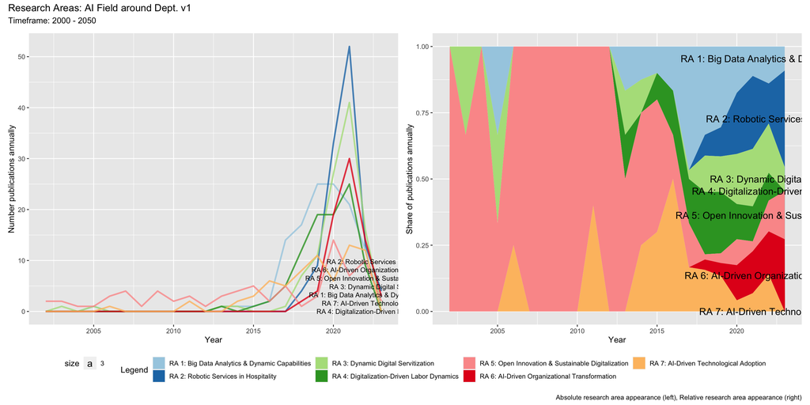

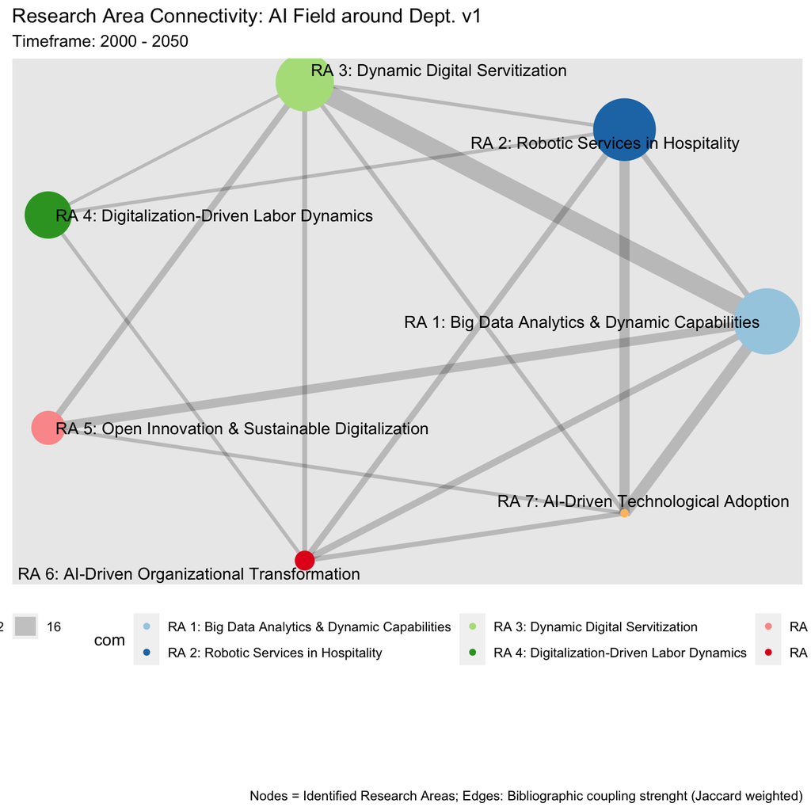

## Automated (LMM) summary

```
## Label: RA 1: Big Data Analytics and Dynamic Capabilities
##   Description: The prevailing research theme among the provided articles is the exploration of big data analytics capabilities (BDAC) and their influence on firm performance, specifically through the lens of the resource-based view and dynamic capabilities theory. These articles collectively argu…
##
##
## Label: RA 2: Robotic Services in Hospitality
##   Description: Research on robotic and AI services in the hospitality industry has seen a significant surge, especially in the context of their interaction with humans. Studies have explored hotel managers' perceptions, consumers' preferences, and the impact of global events such as the COVID-19 …
##
##
## Label: RA 3: Dynamic Digital Servitization
##   Description: The overarching theme across these documents is the integration and transformation of businesses through digitalization, with a specific emphasis on the concept of servitization. Drawing on the theory of dynamic capabilities, the articles collectively explore how firms sense, seize…
##
##
## Label: RA 4: Digitalization-Driven Labor Dynamics
##   Description: The confluence of digitalization and sustainability is significantly reshaping labor market dynamics. Central to this transformation are technologies like industrial robots, automation, and software algorithms that potentially substitute or complement human labor. While these advan…
##
##
## Label: RA 5: Open Innovation and Sustainable Digitalization
##   Description: The overarching research theme in the provided documents centers on the intersection of open innovation and sustainable digitalization in various organizational contexts. At its core, these studies emphasize the evolution and broadening of the open innovation paradigm, showing its …
##
##
## Label: RA 6: AI-Driven Organizational Transformation
##   Description: The burgeoning field of artificial intelligence (AI) is revolutionizing various sectors, notably reshaping the dynamics of organizational practices and industry innovations. Central to these studies is the socio-technical systems (STS) theory, emphasizing the synergy between AI and…
##
##
## Label: RA 7: AI-Driven Technological Adoption
##   Description: Research themes consistently focus on understanding the determinants and influencing factors behind the adoption of new technologies, especially those enhanced by artificial intelligence. They utilize frameworks like the Technology Acceptance Model (TAM) and Task-Technology Fit (TT…
##
##
```

# Collaboration

## Collaboration network

[output not shown]

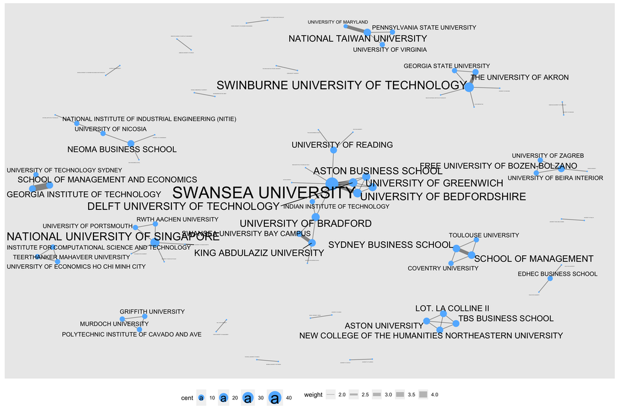